# AMalik03_OriginalHomeworkCode_04

Allister Malik

2023-11-18

## Part 1

Using the “KamilarAndCooperData.csv” dataset, run a linear regression looking at log(HomeRange_km2) in relation to log(Body_mass_female_mean) and report your β coeffiecients (slope and intercept).

First, lets load in necessary packages

```r
library(ggplot2)
library(curl)
library(lmodel2)
```

```r
KC <- curl("https://raw.githubusercontent.com/fuzzyatelin/fuzzyatelin.github.io/master/AN588_Fall23/KamilarAndCooperData.csv")
KC <- read.csv(KC, header = TRUE, sep = ",", stringsAsFactors = FALSE)
head(KC)#Check if its loaded in correctly
```

```
##               Scientific_Name          Family          Genus      Species
## 1 Allenopithecus_nigroviridis Cercopithecidae Allenopithecus nigroviridis
## 2         Allocebus_trichotis Cercopithecidae      Allocebus    trichotis
## 3           Alouatta_belzebul        Atelidae       Alouatta     belzebul
## 4             Alouatta_caraya        Atelidae       Alouatta       caraya
## 5            Alouatta_guariba        Atelidae       Alouatta      guariba
## 6           Alouatta_palliata        Atelidae       Alouatta     palliata
##   Brain_Size_Species_Mean Brain_Size_Female_Mean   Brain_size_Ref
## 1                   58.02                  53.70 Isler et al 2008
## 2                      NA                     NA
## 3                   52.84                  51.19 Isler et al 2008
## 4                   52.63                  47.80 Isler et al 2008
## 5                   51.70                  49.08 Isler et al 2008
## 6                   49.88                  48.04 Isler et al 2008
##   Body_mass_male_mean Body_mass_female_mean Mass_Dimorphism
```

[output cut: 62 more lines]

```r
#Nice! Its loaded in, now lets make the linear regression of log(HomeRange_km2) in relation to log(Body_mass_female_mean). . . seems easy enough
KClin <- lm(log(HomeRange_km2) ~ log(Body_mass_female_mean), data = KC) #linear regression model y ~ x, homerange in realtion to body mass
summary(KClin) #check in on our linear regression
```

```
##
## Call:
## lm(formula = log(HomeRange_km2) ~ log(Body_mass_female_mean),
##     data = KC)
##
## Residuals:
##     Min      1Q  Median      3Q     Max
## -3.3929 -0.9433 -0.0126  1.0944  3.6826
##
## Coefficients:
##                            Estimate Std. Error t value Pr(>|t|)
## (Intercept)                -9.44123    0.67293  -14.03   <2e-16 ***
## log(Body_mass_female_mean)  1.03643    0.08488   12.21   <2e-16 ***
## ---
## Signif. codes:  0 '***' 0.001 '**' 0.01 '*' 0.05 '.' 0.1 ' ' 1
##
## Residual standard error: 1.423 on 135 degrees of freedom
##   (76 observations deleted due to missingness)
## Multiple R-squared:  0.5248, Adjusted R-squared:  0.5213
## F-statistic: 149.1 on 1 and 135 DF,  p-value: < 2.2e-16
```

```r
KClin$coefficients
```

```
##                (Intercept) log(Body_mass_female_mean)
##                  -9.441231                   1.036432
```

Based on the linear regression performed above, the β1, or slope, of the linear regression is 1.036432 and the β0, or the intercept, of the regression is -9.441231. So there is a positive relationship between HomeRangekm_2 and Body_mass_female_mean.

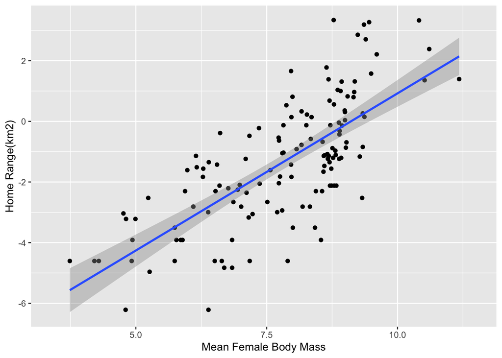

```r
#Lets try plotting it to better visualize the data
x <- log(KC$Body_mass_female_mean)
y <- log(KC$HomeRange_km2)
#Set the two variables to a simpler name, object x and y, for my variables
g <- ggplot(data = KC, aes(x = x, y = y))
g <- g + geom_point() #scatter plot the data
g <- g + labs(x = "Mean Female Body Mass", y = "Home Range(km2)") #label them because just having them as x and y
g <- g + geom_smooth(method = "lm", formula = y ~ x) #add the regression line
g #lets see it
```

## Part 2

Use bootstrapping to sample from your data 1000 times with replacement, each time fitting the same model and calculating the same coefficients. This generates a sampling distribution for each β coefficient.

```r
data <- data.frame(x, y) #Gives the log(body mass) and log(homerange) of dataset
samplerows <- NULL #sampled row number dummy variable
sampledata <- NULL #sampled data dummy
samplecoef <- data.frame()
n = 1000
for (i in 1:1000) { #do this thing 1000 times
     samplerows <- sample(nrow(data), size = n, replace = TRUE) #sample a number corresponding to a row, with replacement to get 1000 rows
    sampledata <- data[samplerows, ] #sample dataframe of the actual values

  m <- lm(y ~ x, data = sampledata) ##Now to fit it to a linear model



  c <- coefficients(m)
  samplecoef[i, 1] <- c[1]
  samplecoef[i, 2] <- c[2]
  #I tried samplecoef <- coeff(m) but it created a dataframe with 0 columns and 1000 rows, had to do it a more rudimentary and longer way
}
colnames(samplecoef) <- c("β0", "β1")
summary(samplecoef) #Let see it. . . it looks right
```

```
##        β0                β1
##  Min.   :-10.346   Min.   :0.9378
##  1st Qu.: -9.622   1st Qu.:1.0123
##  Median : -9.432   Median :1.0351
##  Mean   : -9.446   Mean   :1.0371
##  3rd Qu.: -9.258   3rd Qu.:1.0604
##  Max.   : -8.695   Max.   :1.1476
```

Estimate the standard error for each of your β coefficients as the standard deviation of the sampling distribution from your bootstrap and determine the 95% CI for each of your β coefficients based on the appropriate quantiles from your sampling distribution.

```r
#"Make" the population standard deviation funtion AKA copy and paste from my previous HW assignment.
pop_sd <- function(x) {
  sqrt(
    sum((x - mean(x))^2)/(length(x))
  )
}
#Estimate standard errors of the coefficients
(B0se <- pop_sd(samplecoef$β0))
```

```
## [1] 0.2821456
```

```r
(B1se <- pop_sd(samplecoef$β1))
```

```
## [1] 0.03656682
```

```r
#Calculate 95% CI's for the coefficients:
b0ci <- quantile(samplecoef$β0, c(0.025, 0.975))
b1ci <- quantile(samplecoef$β1, c(0.025, 0.975))

b0ci
```

```
##       2.5%      97.5%
## -10.049020  -8.926885
```

```r
b1ci
```

```
##     2.5%    97.5%
## 0.969556 1.115028
```

How does the former compare to the SE estimated from your entire dataset using the formula for standard error implemented in lm()?

The SE estimated from the entire dataset using the formula yields a larger number when compared to the SE estimated using the SD of the sample data

How does the latter compare to the 95% CI estimated from your entire dataset?

The 95% CI’s estimated of the entire dataset is larger than than CI of the sampled data.